# Data Wrangling with R (CSP1004)

Pre-course Assignment

Eric Kelchlin - Course Leader

The National Conservation Training Center

eric_kelchlin@fws.gov

(304) 876-7453

Updated on 2019-03-25

# Class Logistics

- **When:** January 13-17, 2020
- **Times:** 8:30 am - 4:30 pm
- **Last Day End Time:** 11:30 am
- **Rough Agenda (subject to change):**

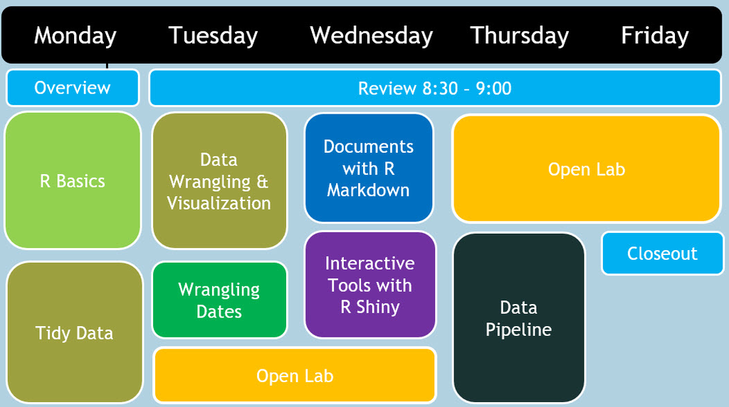

- **Class location:** The National Conservation Training Center, 698 Conservation Way, Shepherdstown, WV 25443
- **Class Room:** G30 Instructional East
- Download a [PDF Map of Campus](https://nctc.fws.gov/documents/Campus-Map.pdf)

## An Interactive Map of the NCTC Campus

[interactive chart not shown]

# Frequently Asked Questions

### Do I need to bring my laptop to class?

*Answer:* It depends. If your class is at the National Conservation Training Center (NCTC), then bringing your laptop to class is optional. We’ll provide you with a computer during class, but you may want to work after hours with your own laptop. If your class is not at NCTC, then it is required that you bring your laptop with the software installed and configured according to the steps listed in the **Software Installation** section.

### Do I need to install the class software on my work computer?

*Answer:* Yes. You’ll need to have **R** and the **R Studio** IDE installed to complete the online training. Also, we want you to hit the ground running when you come back from class.

### My IT staff will not install the software on my work computer, what do I do?

*Answer:* Perform acts of kindness. IT actually loves open source software and it’s preferred over comercial software in the Federal Government.

# Mandatory Precourse Homework

Install **R** and **R Studio** (see Step 1 below) and complete the two online classes from Data Camp. This should take you about 3 hours each. The second online class is more challenging, but it’s even more applicable to what we teach in class, so give it your best shot.

- [R for the Intimidated](https://www.datacamp.com/community/open-courses/r-for-the-intimidated)
- [Getting and Cleaning Data](https://www.datacamp.com/community/open-courses/getting-and-cleaning-data-with-swirl)

# Software Installation

The tabs below will guide you through the installation of softwere necessary for the class. I futher show you how to configure **R Studio** and how to install the class materials.

## R & R Studio

Download and install the most current versions of **R** and **RStudio** for your operating system. Install R in your User folder (i.e., `C:\Users\ekelchlin\Documents\R`), so you won’t need administrative rights. However, you’ll need administrative rights for R Studio.

- [R - Windows](https://cran.r-project.org/bin/windows/base/)
- [R - Mac](https://cran.r-project.org/bin/macosx/)
- [RStudio](https://www.rstudio.com/products/rstudio/download/)

*Note: To open the link in a new browser tab, right-mouse click on the link and select Open link in new tab.*

## R Packages

The instructions below will guide through a process on how to install R packages used in class. You can think of packages as “little add-ons” that expand what you can do in R. [Tidyverse](https://www.tidyverse.org/), for example, is one of my favorite packages for data science.

- Open R Studio, select **File > New File > R Script**. This creates a new R script file and opens a new tab called `Untitled1` in the Source window pane.

[figure not shown]

- Highlight and copy the code below. Paste the code in the new R script file. *This is a custom function (geesh! so fancy already) that looks to see if you already have the package installed and if not, it will install the package for you. More on packages later in the class.*

```r
packages <- function(x){
  x <- as.character(match.call()[[2]])
  if (!require(x,character.only = TRUE)) {
    install.packages(pkgs = x,repos = "http://cran.r-project.org")
    require(x,character.only = TRUE)
  }
}
```

- Highlight the entire code block and click the **run** button. This will add a new function called `packages` in the Environment pane.

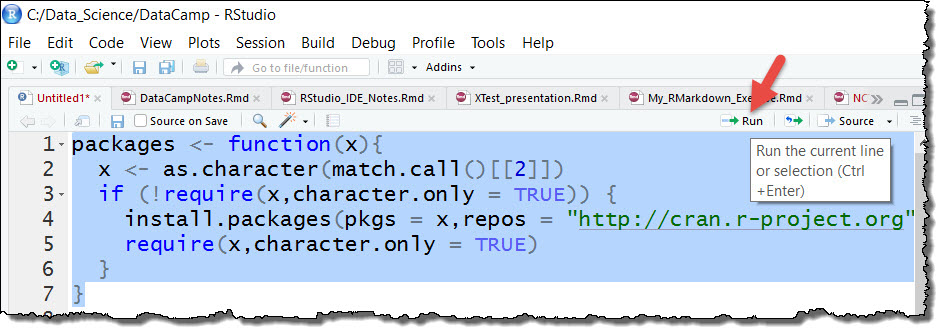

- Next, highlight and copy the code below and paste in the R script file below the packages function section (i.e., line 9).

```r
packages(knitr)
packages(rmarkdown)
packages(tidyverse)
packages(tinytex)
packages(yaml)
packages(here)
packages(kableExtra)
packages(devtools)
packages(leaps)
packages(leaflet)
packages(maps)
packages(mapview)
packages(maptools)
packages(odbc)
packages(plotly)
packages(pom)
packages(pwr)
packages(raster)
packages(rgbif)
packages(rgdal)
packages(ROCR)
packages(sf)
packages(data.table)
packages(spocc)
packages(sp)
packages(survey)
packages(spsurvey)
packages(tigris)
```

- Highlight this new block of code and click the **run** button again. This will download packages and add them to your R library. You should see a lot of red, blue and black text scrolling up in the Console pane. The installation process will take about 30 seconds.

[figure not shown]

Your packages will be saved in the library folder. To find out where all the packages live, simply copy the code below, paste in the Source pane and run the code.

```r
.libPaths()
```

```
## [1] "C:/Users/ekelchlin/Documents/R/R-3.5.2/library"
```

## MikTeX

Install **MiKTeX** applications for use with [R Markdown](https://rmarkdown.rstudio.com/). This will allow you to publish PDF documents and provide some cool syntax to further customize your documents. They will run in the background and can be ignored from this point forward.

### How to Install MiKTeX (Full Version)

- Click this link [MiKTeX](https://miktex.org/2.9/setup)
- Download the Net Installer

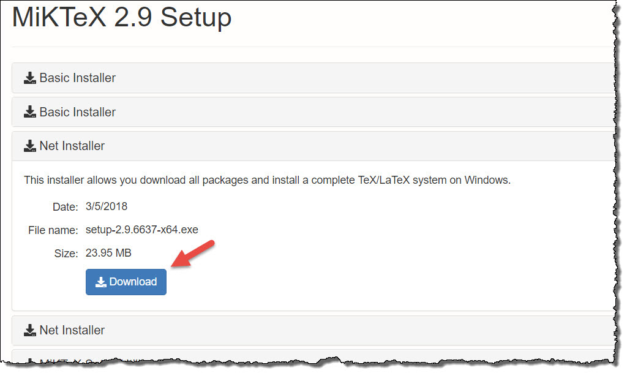

- Click the downloaded file to start the installation. Click the *I accept…* box and the **Next** button.

[figure not shown]

- Download the MiKTeX program. It’s a 2GB file, so it’s best to go plunder the fridge for some food. Take stock of your life and come back to finish the installation process.

[figure not shown]

- Once the file is downloaded, click the next radio button to install the program. Install the program only for you and place in your **Documents** folder.

[figure not shown]

- MiKTeX should be in your program list when done.

[figure not shown]

## R Studio Settings

Let’s walk through some R Studio settings to standardize the look and feel of the Integrated Development Environment (IDE). This will allow the instructor(s) to respond quicker when you run into a glitch or an error. These settings will also speed-up your learning process.

Open R Studio and select **Tools > Global Options…** from the top menu bar.

### General R Options

- Change the default working directory to the class folder.
- Also, check the boxes as shown below.

[figure not shown]

### Source Code: Editing

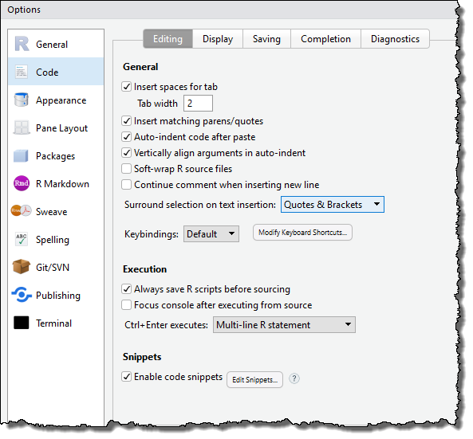

### Source Code: Display

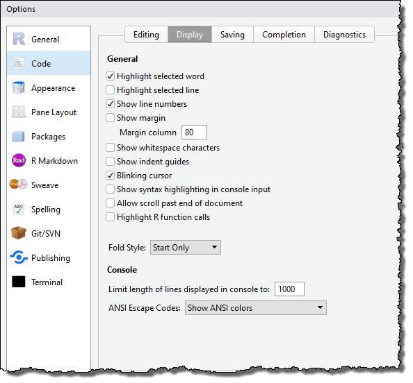

### Source Code: Saving

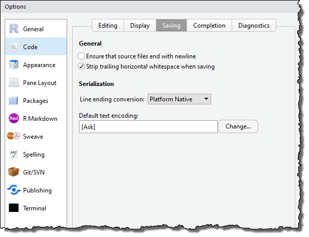

### Source Code: Completion

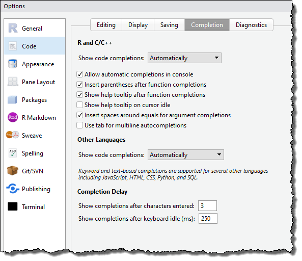

### Source Code: Diognostics

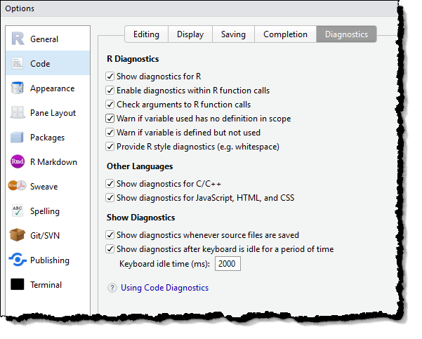

### Appearance and Themes

- I use the **TexeMate(default)** theme or my new favorite the **Dracula** theme for those who like it dark and bloody.
- I keep the font large, because lets face it, we are not getting any younger.

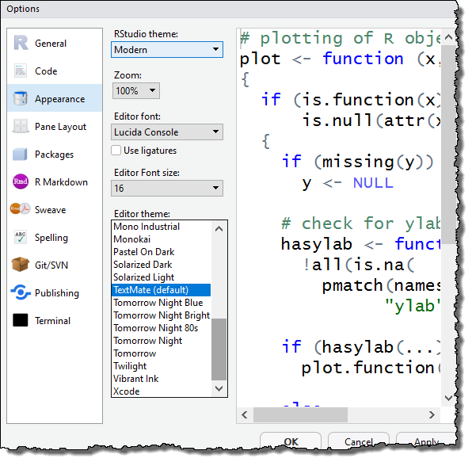

### Pane Layout

[figure not shown]

### Packages

[figure not shown]

### RMarkdown

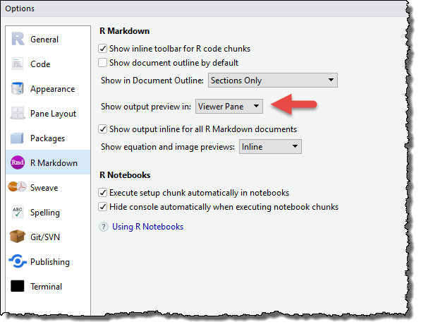

### Sweave on Down

[figure not shown]

## Class Data

I’ll share the course materials from my Google Drive or as a compressed zip file. Everything will be in one folder, named as **CSP1004_date**. Take this folder, extract if necessary, and save it on the root of your `C:\` Drive. Rename the folder **CSP1004**.

# Help with Learning R

R is powerful language that is limited only by your imagination. I’ve include a bunch of sites below that I hope you find as useful as I did when I was learning R on my own.

## R Tutorials

- [RStudio Essentials Video](https://www.rstudio.com/resources/webinars/rstudio-essentials-webinar-series-part-1/) – Learn the basics of how to navigate the RStudio IDE
- [Quick R](https://www.statmethods.net/)
- [R Basics](https://sejdemyr.github.io/r-tutorials/basics/)
- [R for Fledglings - University of Vermont](https://www.uvm.edu/rsenr/vtcfwru/R/?Page=fledglings/fledglings.htm)
- [R Tutorial - University of Georgia](http://www.cyclismo.org/tutorial/R/index.html)
- [Machine Learning](https://www.r-bloggers.com/in-depth-introduction-to-machine-learning-in-15-hours-of-expert-videos/)

## Favorites

- [Awesome Graphs with ggplot2](http://ggplot2.tidyverse.org/reference/)
- [Data Processing with dplyr & tidyr](https://rpubs.com/bradleyboehmke/data_wrangling)
- [RMarkdown HTML Documents](https://rmarkdown.rstudio.com/html_document_format.html)
- [Markdown Syntax](https://daringfireball.net/projects/markdown/)
- [Learn ggplot syntax with a shiny app](http://databall.co/shiny/shinyggplot/?utm_source=r-bloggers.com&utm_medium=referral&utm_campaign=blogpost&utm_content=text)

## R Books

- [Free R Books from Bookdown](https://bookdown.org/)
- [R for Data Science](http://r4ds.had.co.nz/) – If you could read only one book, this is it!
- [Cookbook for R](http://www.cookbook-r.com/)
- [Ecological Models and Data in R](http://ms.mcmaster.ca/~bolker/emdbook/)
- [LeanPub - books and classes](https://leanpub.com/bookstore/type/book/sort/earnings_in_last_7_days?search=data)

## Help X2

- [RStudio - Getting Help with R](https://support.rstudio.com/hc/en-us/articles/200552336)
- [RStudio Cheat Sheets](https://www.rstudio.com/resources/cheatsheets/)
- [R Seek - Google for R](https://rseek.org/)
- [R Bloggers](https://www.r-bloggers.com/)
- [R Publications](http://rpubs.com/)

## Online Classes

- [RStudio Online Learning](https://www.rstudio.com/online-learning/)
- [DataCamp](https://www.datacamp.com/home)
- [Udemy](https://www.udemy.com/courses/search/?ref=home&src=ukw&q=R)
- [Coursera](https://www.coursera.org/courses?languages=en&query=R)
- [Lynda.com](https://www.lynda.com/R-training-tutorials/1570-0.html)
- [Statistics.com](https://www.statistics.com/landing-page/r-courses/)

[figure not shown]